# R Programming Sample

James McCarthy

2023-07-30

# Introduction

Welcome to my R programming sample!

In this program, I attempt to confirm that on average, the number of vehicle collisions and number of injuries and fatalities due to collisions are higher on days of inclement weather in Manhattan from 2013 to 2021 than on those of clement weather.

Using precipitation data from NOAA’s central park weather station acquired through a request on their website as well as vehicular collisions data from the NYPD acquired through NYC Open Data, I will quality check, modify, aggregate, merge, visualize, and model this data to confirm my hypothesis that precipitation is associated with traffic incidents in the borough of Manhattan.

# Libraries

```r
# import libraries
library("tidyverse")
library("magrittr") #pipes
library("stats") #glm regressions
library("psych") # correlations
library("naniar") # easy missingness checks
library("janitor") # easy dupe counts
library("gtools") # p stars
library("knitr") # knitting options
library("kableExtra") # more knitting options
library("statmod") #tweedie index maximum likelihood
library("tweedie") #tweedie regressions
library("glmnet") # lasso, ridge, elastic net regressions
library("randomForest") # random forest regression
library("neuralnet") # neural net regression

#scroll_box global height/width parameters set for kable objects
formals(scroll_box)$height <- "500px"
formals(scroll_box)$width <- "100%"
```

# General functions

```r
# Function to output nicely formatted tables in this knitted rmd
#
# Parameters:
# .df: dataset
# .caption: optional argument to caption table, defaults to empty string
# .fwidth: optional argument to specify table to use full width, defaults to FALSE
# .column_names: optional argument to assign names to table, defaults to NA
#
# Returns:
# kable object of original dataset with booktabs theme and potential caption

kable_table <- function(.df, .caption = '', .fwidth = F, .column_names = NA){
  kable_item <- .df %>%
    kableExtra::kbl(caption = .caption, booktabs = T, col.names = .column_names) %>% #kable object, booktabs theme, caption specify
    kableExtra::kable_classic(full_width = .fwidth) %>% #Ekable_classic theme, not full width
    kableExtra::kable_styling(bootstrap_options = c('striped', 'hover'), latex_options = "HOLD_position") #for rowwise readability, table placement in knitted doc

  return(kable_item)
}
```

```r
# Function to make ggplot output generally prettier and standardized theme
#
# Parameters:
# None
#
# Returns:
# NULL
ggtheme <- function(){
  theme_bw() +
  theme(panel.grid.major = element_blank(), #remove major grid lines
        panel.grid.minor = element_blank(), #remove minor grid lines
        panel.border = element_blank(), # remove border
        axis.line = element_line(color = "black"), #axis line black
        axis.title.y = element_text(angle = 0, vjust = 0.5), #y axis labels horizontal, centered
        plot.title = element_text(face = "bold", hjust = 0.5, size = 11)) #bold title, centered
}
```

# Data Read In

```r
#root data directory path
data_root <- "C:/Users/jmcca/OneDrive/Documents/Data"

# Local climatological data from NOAA's Central Park Station
# Hourly Level Data
# Date Range = Jan 1, 2013 - Dec 31, 2021
weather <- read_csv(file.path(data_root, "NOAA_LCD_Central_Park_2013_2021.csv")) %T>%
  glimpse()

#NYPD Vehicle Collision Data
# Collision Level Dataset - all police reported collisions/num_crashes across NYC
collisions <- read_csv(file.path(data_root, "NYPD_Motor_Vehicle_Collisions.csv")) %T>%
  glimpse()
```

# Quality Check

## Weather Data

This dataset from NOAA contains information about observed weather phenomena in Central Park, Manhattan from 2013 to 2021. It is hourly level, with dedicated rows for daily and monthly summaries. I will primarily be interested in the precipitation items, although this dataset contains a plethora of information on other values such as temperature, pressure, humidity, visibility, etc.

```r
#duplicate col names existed in weather when read in
#R appended column position to name

#wondering if these columns are simply dupes
weather %>%
  select(matches('SOURCE')) %>%
  distinct()

weather %>%
  select(matches('REPORT_TYPE')) %>%
  distinct()
#seems like both sets of columns are indeed duplicates
```

```r
#drop the latter duplicate columns and rename former
weather_names_mod <- weather %>%
  select(-c("REPORT_TYPE...96", "SOURCE...97")) %>%
  rename(REPORT_TYPE = REPORT_TYPE...3,
         SOURCE = SOURCE...4)
```

### Missingness

```r
#checking missingness
weather_names_mod %>%
  naniar::miss_var_summary() %>%
  kable_table("Missingess summary, weather")%>%
  scroll_box()
```

Missingess summary, weather

| variable | n_miss | pct_miss |
| --- | --- | --- |
| BackupElevation | 104657 | 100.000000 |
| BackupElevationUnit | 104657 | 100.000000 |
| BackupLatitude | 104657 | 100.000000 |
| BackupLongitude | 104657 | 100.000000 |
| MonthlyAverageRH | 104657 | 100.000000 |
| MonthlyDewpointTemperature | 104657 | 100.000000 |
| MonthlyWetBulb | 104657 | 100.000000 |
| DYHF | 104654 | 99.997134 |
| DYTS | 104653 | 99.996178 |
| MonthlyGreatestSnowDepthDate | 104625 | 99.969424 |
| MonthlyTotalSnowfall | 104623 | 99.967513 |
| MonthlyGreatestSnowfallDate | 104610 | 99.955091 |
| AWND | 104562 | 99.909227 |
| ShortDurationEndDate180 | 104562 | 99.909227 |
| ShortDurationPrecipitationValue180 | 104562 | 99.909227 |
| ShortDurationEndDate005 | 104560 | 99.907316 |
| ShortDurationEndDate010 | 104560 | 99.907316 |
| ShortDurationEndDate015 | 104560 | 99.907316 |
| ShortDurationEndDate020 | 104560 | 99.907316 |
| ShortDurationEndDate030 | 104560 | 99.907316 |
| ShortDurationEndDate045 | 104560 | 99.907316 |
| ShortDurationEndDate060 | 104560 | 99.907316 |
| ShortDurationEndDate080 | 104560 | 99.907316 |
| ShortDurationEndDate100 | 104560 | 99.907316 |
| ShortDurationEndDate120 | 104560 | 99.907316 |
| ShortDurationEndDate150 | 104560 | 99.907316 |
| ShortDurationPrecipitationValue005 | 104560 | 99.907316 |
| ShortDurationPrecipitationValue010 | 104560 | 99.907316 |
| ShortDurationPrecipitationValue015 | 104560 | 99.907316 |
| ShortDurationPrecipitationValue020 | 104560 | 99.907316 |

[output cut: 92 more lines]

There is a good amount of missingness for many variables, but the Date column is never missing which is helpful for merging later on. Since this is an hourly level dataset, the missingness by monthly and daily variables doesn’t concern me too much.

### Dates

```r
#confirming date range is as expected
weather_names_mod %>%
  summarise(earliest = min(as.Date(DATE), na.rm = T),
            latest = max(as.Date(DATE), na.rm = T),
            .groups = "drop") %>%
  kable_table("Weather, date range")
```

Weather, date range

| earliest | latest |
| --- | --- |
| 2013-01-01 | 2021-12-31 |

### Duplicates

```r
#check for duplicates overall
weather_names_mod %>%
  janitor::get_dupes()
# no dupes when considering all columns

#check for dupes by date
weather_names_mod %>%
  janitor::get_dupes(DATE)
#It appears there are duplicates by days by REPORT_TYPE variable
#I can't find any info about this variable in documentation

#check how many REPORT_TYPE values exists, count
weather_names_mod %>%
  group_by(REPORT_TYPE) %>%
  summarise(n=n(), .groups = "drop")
#SOM appears 108 times- number of months in 9 years of data
#SOD appears 3287 times

#get number of days between min and max dates
difftime("2021-12-31", "2013-01-01", units = "days")
#when inclusive, this matches number of SOD appearances
```

```r
# What I glean is as follows
# REPORT_TYPE: SOD (Summary of Day) because daily variables are non null
# REPORT_TYPE: SOM (Summary of Month) because monthly variables are non null
# Other REPORT_TYPE are hourly reports

# REPORT_TYPE values FM-15 and FM-16 (hourly reports) seem to have dupes on occasion by time
# however i'm not planning to use hourly data here, just daily and monthly summaries

#check that no dupes exist by DATE and REPORT_TYPE
weather_names_mod %>%
  janitor::get_dupes(DATE, REPORT_TYPE)
#none - looks good to me
```

### Weather Codes

In this section, I will check if the observed weather types (DailyWeather column contains codes for different kinds of weather) generally matches if precipitation occurred in Manhattan. This is a good internal consistency check on the weather data to make sure precipitation is believable.

```r
#check distinct values in DailyWeathers
weather_names_mod %>%
  select(DailyWeather) %>%
  distinct()
#many combinations of observed weather types
```

```r
#vector of weather codes in DailyWeather that could cause precipitation
precip_codes <- c('BLSN', 'DZ', 'FZDZ', 'RA', 'FZRA', 'SN', 'UP')

weather_names_mod_check <- weather_names_mod %>%
  #filter for daily weather
  filter(REPORT_TYPE == 'SOD') %>%
  #dummy indicating if any of the above weather codes were observed for each day
  mutate(precip_codes = case_when(grepl(paste(precip_codes, collapse = "|"), DailyWeather) ~ 1,
                                       T ~ 0),
         #dummy for Daily Precipitation above 0
         measurable_precip = case_when(DailyPrecipitation > 0 ~ 1,
                                       DailyPrecipitation == 0 ~ 0,
                                     T ~ NA_real_))
```

```r
#check this was made right, distinct values of DailyWeather and inclement_weather
weather_names_mod_check %>%
  select(DailyWeather, precip_codes) %>%
  distinct()
#lgtm
```

```r
#check if observed weather dummy matches any measurable precipitation dummy
weather_names_mod_check %>%
  group_by(precip_codes, measurable_precip) %>%
  summarise(n=n(), .groups = "drop") %>%
  mutate(total = sum(n),
         percent_total = 100 * round(n/total, 4)) %>%
  select(-total) %>%
  kable_table("Check of precip_codes versus measurable_precip")
```

Check of precip_codes versus measurable_precip

| precip_codes | measurable_precip | n | percent_total |
| --- | --- | --- | --- |
| 0 | 0 | 1847 | 56.19 |
| 0 | 1 | 36 | 1.10 |
| 0 | NA | 138 | 4.20 |
| 1 | 0 | 10 | 0.30 |
| 1 | 1 | 1131 | 34.41 |
| 1 | NA | 125 | 3.80 |

About 90% of days with observed weather codes that could cause precipitation are also on days with non-zero precipitation. This data seems fairly consistent, especially as excluding missing precipitation days causes true mismatches to be <2%.

## Collisions Data

This dataset from NYC Open Data contains information on NYPD vehicular incident reports in New York City from roughly 2012 to 2023. It is report level, meaning each row represents a collision. While there are some interesting open ended columns such as contributing factors, I will be primarily interested in the number of injuries and fatalities reported as well as simply the number of rows (collisions) reported on each day.

### Missingness

```r
collisions %>%
  naniar::miss_var_summary() %>%
  kable_table("Missingess summary collisions") %>%
  scroll_box()
```

Missingess summary collisions

| variable | n_miss | pct_miss |
| --- | --- | --- |
| VEHICLE TYPE CODE 5 | 1985063 | 99.5860662 |
| CONTRIBUTING FACTOR VEHICLE 5 | 1984811 | 99.5734240 |
| VEHICLE TYPE CODE 4 | 1962840 | 98.4711892 |
| CONTRIBUTING FACTOR VEHICLE 4 | 1961798 | 98.4189144 |
| VEHICLE TYPE CODE 3 | 1857344 | 93.1786964 |
| CONTRIBUTING FACTOR VEHICLE 3 | 1852521 | 92.9367375 |
| OFF STREET NAME | 1668062 | 83.6828518 |
| CROSS STREET NAME | 742551 | 37.2520837 |
| ZIP CODE | 620308 | 31.1194323 |
| BOROUGH | 620028 | 31.1053853 |
| ON STREET NAME | 417668 | 20.9534474 |
| VEHICLE TYPE CODE 2 | 369025 | 18.5131394 |
| CONTRIBUTING FACTOR VEHICLE 2 | 302515 | 15.1764850 |
| LATITUDE | 227675 | 11.4219335 |
| LONGITUDE | 227675 | 11.4219335 |
| LOCATION | 227675 | 11.4219335 |
| VEHICLE TYPE CODE 1 | 12318 | 0.6179659 |
| CONTRIBUTING FACTOR VEHICLE 1 | 6207 | 0.3113910 |
| NUMBER OF PERSONS KILLED | 31 | 0.0015552 |
| NUMBER OF PERSONS INJURED | 18 | 0.0009030 |
| CRASH DATE | 0 | 0.0000000 |
| CRASH TIME | 0 | 0.0000000 |
| NUMBER OF PEDESTRIANS INJURED | 0 | 0.0000000 |
| NUMBER OF PEDESTRIANS KILLED | 0 | 0.0000000 |
| NUMBER OF CYCLIST INJURED | 0 | 0.0000000 |
| NUMBER OF CYCLIST KILLED | 0 | 0.0000000 |
| NUMBER OF MOTORIST INJURED | 0 | 0.0000000 |
| NUMBER OF MOTORIST KILLED | 0 | 0.0000000 |
| COLLISION_ID | 0 | 0.0000000 |

```r
#fair amount of collisions missing Borough
#no dates missing though which is helpful
#also number injured is rarely missing - primarily interested in these items
```

### Dates

```r
#first need to convert crash date from character to date type
collisions_date_mod <- collisions %>%
  #while im at it, create crash indicator since each row represents a collision
  mutate(crash_date = as.Date(`CRASH DATE`, format = "%m/%d/%Y"),
         num_crashes = 1) %>%
  #relocate date column first
  relocate(crash_date)

#now check date range
collisions_date_mod %>%
  summarise(earliest = min(crash_date),
            latest = max(crash_date),
            .groups = "drop") %>%
  kable_table("Collisions, date range")
```

Collisions, date range

| earliest | latest |
| --- | --- |
| 2012-07-01 | 2023-05-16 |

### Duplicates

```r
#check duplicates of collision id in collisions
collisions_date_mod %>%
  group_by(COLLISION_ID) %>%
  summarise(n_dupes = n(), .groups = "drop") %>%
  filter(n_dupes > 1)
#0 rows, all collisions entries appear to be unique
```

# Analysis Dataset Creation

The quality checks look good to me. Both weather and collisions datasets have been slightly modified in the previous section, but now I will modify them for the analysis dataset creation.

My goal is to use a daily level dataset for analysis. This will require extracting the daily precipitation summaries from the weather data and aggregating the incident level collisions data to a daily value with a sum.

### Modifying Weather

```r
#weather: instead of aggregating hourly data, will simply filter for summary of day reports
daily_weather <- weather_names_mod %>%
  filter(REPORT_TYPE == 'SOD') %>%
  #im not interested in datetime, just date - omit time
  mutate(date = as.Date(DATE)) %>%
  #select relevant columns to keep
  select(date, contains('Daily')) %>%
  #263 obs missing precipitation, 128 snowfall, 38 snowdepth - seems right to impute these with 0
  mutate(DailyPrecipitation = case_when(is.na(DailyPrecipitation) ~ 0,
                                        T ~ DailyPrecipitation),
         DailySnowfall = case_when(is.na(DailySnowfall) ~ 0,
                                   T ~ DailySnowfall),
         DailySnowDepth = case_when(is.na(DailySnowDepth) ~ 0,
                                   T ~ DailySnowDepth)) %T>%
  print()

#double check for na
daily_weather %>%
  miss_var_summary()
#everything im interested in is not na/has been imputed
```

```r
#the DailyWeather item contains codes for different type of observed weather that day
daily_weather %>%
  select(DailyWeather) %>%
  distinct()

#could make a precipitation present dummy based on whether some select codes are present on a daily basis
```

### Modifying Collisions

```r
#now back to collisions data
#keep just collisions that occurred in Manhattan
#filter dates to match weather data - only keep collisions within 1/1/13 - 12/13/21
daily_collisions <- collisions_date_mod %>%
  filter(BOROUGH == 'MANHATTAN' & (crash_date >= as.Date("2013-01-01") & crash_date <= as.Date("2021-12-31"))) %>%
  #aggregate by date
  group_by(crash_date) %>%
  #sum num_crashes and number injured/killed to daily basis
  summarise(across(matches("num_crashes|NUMBER"), ~sum(., na.rm = T)),
            .groups = "drop") %T>%
  print()
#same number of rows as daily weather, so there must be at least 1 crash per day in manhattan - why i take the subway
```

```r
#replace white spaces with '_' in column names for easier reference
colnames(daily_collisions) <- gsub("\\s", "_", colnames(daily_collisions))

#double check that worked
daily_collisions %>%
  names()
#looks good

#double check missingness
daily_collisions %>%
  naniar::miss_var_summary()
#looks good to me, the few missing injured/killed obs previously must have been in other boroughs
```

```r
#analysis dataset creation
#merging daily weather and collisions data by date
weather_collisions <- full_join(daily_weather,
          daily_collisions,
          by = c('date' = 'crash_date')) %>%
  #might use logged number of crashes in analysis
  mutate(log_num_crashes = log(num_crashes)) %>%
  print()
```

# Pre-Analysis Exploration

In order to better determine the kind of algorithm to use for analysis, I’d like to better understand the data. In this section I will output descriptive statistics, histograms, and correlations of both precipitation and collisions data to get a sense of their range, distribution, and variance. This section could determine if I decide to use a linear or non linear model for evaluation.

```r
#vector of analysis variable names
items_of_interest <- weather_collisions %>%
  select(DailyPrecipitation, DailySnowfall, DailySnowDepth, num_crashes, contains("NUMBER")) %>%
  names()
```

## Descriptive Stats

```r
# Function to calculate descriptive statistics
#
# Parameters:
# .items: vector of string names of data columns to summarize
# .df: dataset
#
# Returns:
# Tibble containing n, n missing, min, Q1, median, Q3, max, mean, and sd for every column specified

desc_stats_tabled <- function(.items, .df) {
  #map over each element of .items
  map_dfr(.items, function(.x) {
    stats_output <- .df %>%
      #stats include n, n missing, range, mean, standard dev
      summarise(n=n(),
                n_miss = sum(is.na(!!sym(.x))),
                min = min(!!sym(.x), na.rm = T),
                Q1 = quantile(!!sym(.x), probs = 0.25, na.rm = T),
                median = quantile(!!sym(.x), probs = 0.5, na.rm = T),
                Q3 = quantile(!!sym(.x), probs = 0.75, na.rm = T),
                max = max(!!sym(.x), na.rm = T),
                mean = round(mean(!!sym(.x), na.rm = T), 2),
                sd = round(sd(!!sym(.x), na.rm = T), 1),
                .groups = "drop") %>%
      #include .item name in output table
      mutate(variable = .x) %>%
      relocate(variable)

    return(stats_output)
  })
}
```

```r
#generate descriptive stats for select items
desc_stats_tabled(.items = items_of_interest,
                  .df =  weather_collisions) %>%
  kable_table("Descriptive stats, collisions and weather items of interest")
```

Descriptive stats, collisions and weather items of interest

| variable | n | n_miss | min | Q1 | median | Q3 | max | mean | sd |
| --- | --- | --- | --- | --- | --- | --- | --- | --- | --- |
| DailyPrecipitation | 3287 | 0 | 0 | 0 | 0 | 0.06 | 7.13 | 0.14 | 0.4 |
| DailySnowfall | 3287 | 0 | 0 | 0 | 0 | 0.00 | 27.30 | 0.09 | 0.8 |
| DailySnowDepth | 3287 | 0 | 0 | 0 | 0 | 0.00 | 22.00 | 0.42 | 2.0 |
| num_crashes | 3287 | 0 | 3 | 56 | 87 | 110.00 | 209.00 | 83.21 | 37.1 |
| NUMBER_OF_PERSONS_INJURED | 3287 | 0 | 0 | 11 | 15 | 20.00 | 56.00 | 15.76 | 6.6 |
| NUMBER_OF_PERSONS_KILLED | 3287 | 0 | 0 | 0 | 0 | 0.00 | 8.00 | 0.08 | 0.3 |
| NUMBER_OF_PEDESTRIANS_INJURED | 3287 | 0 | 0 | 3 | 5 | 7.00 | 32.00 | 5.14 | 3.4 |
| NUMBER_OF_PEDESTRIANS_KILLED | 3287 | 0 | 0 | 0 | 0 | 0.00 | 6.00 | 0.06 | 0.3 |
| NUMBER_OF_CYCLIST_INJURED | 3287 | 0 | 0 | 1 | 3 | 4.00 | 13.00 | 2.91 | 2.1 |
| NUMBER_OF_CYCLIST_KILLED | 3287 | 0 | 0 | 0 | 0 | 0.00 | 2.00 | 0.01 | 0.1 |
| NUMBER_OF_MOTORIST_INJURED | 3287 | 0 | 0 | 5 | 7 | 10.00 | 32.00 | 7.63 | 4.3 |
| NUMBER_OF_MOTORIST_KILLED | 3287 | 0 | 0 | 0 | 0 | 0.00 | 1.00 | 0.01 | 0.1 |

A lot of items have a first quartile of 0, so I think it would be a good idea to look at distributions visually.

## Histograms

```r
# Function to create a histogram
#
# Parameters:
# .item: string name of data column to create a histogram of
# .df: dataset
# .bins: optional argument for number of histogram bins, defaults to 100
# .title: optional argument for title of histogram, defaults to 'Histogram: .item'
#
# Returns:
# ggplot histogram

gghist <- function(.item, .df, .bins = 100, .title = "") {
  #if .title is empty, create a basic one
  if (.title == "") {
    .title = paste("Histogram:", .item, sep = " ")
  }

  #specify item/tibble to generate histogram from
  output <- ggplot(data = .df,
       aes(!!sym(.item))) +
    #specify number of bins, and i like green
    geom_histogram(bins = .bins, fill = "#006400") +
    #ggtheme for cleaner look
    ggtheme() +
    #optional plot title
    ggtitle(.title)

  print(output)
}
```

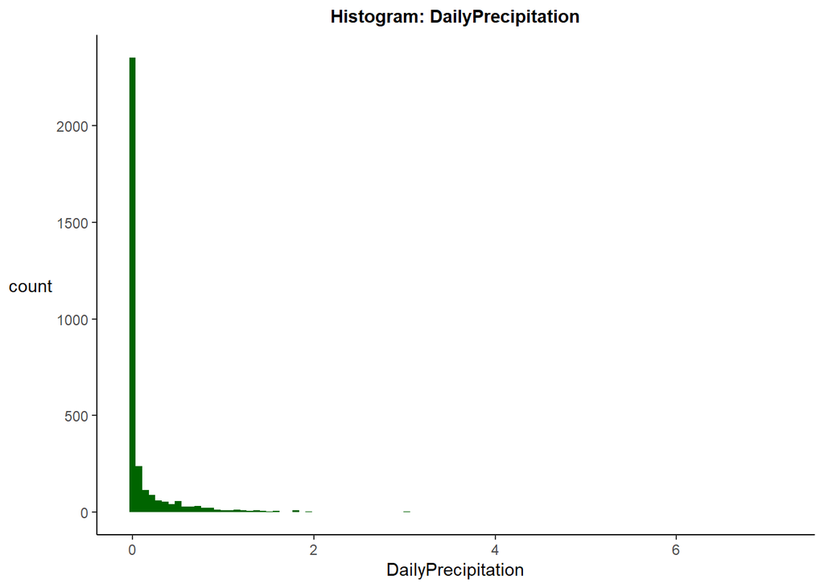

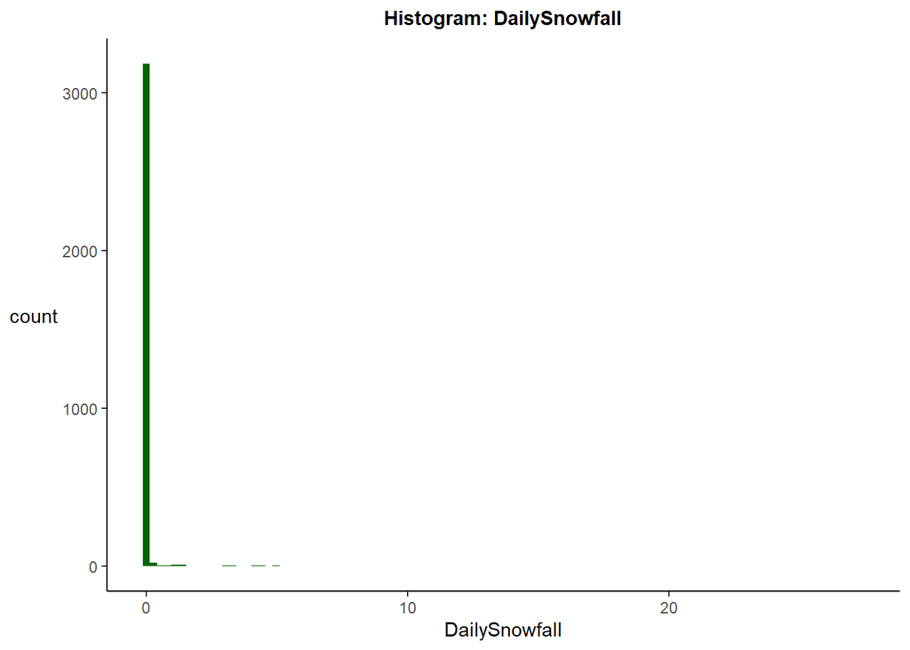

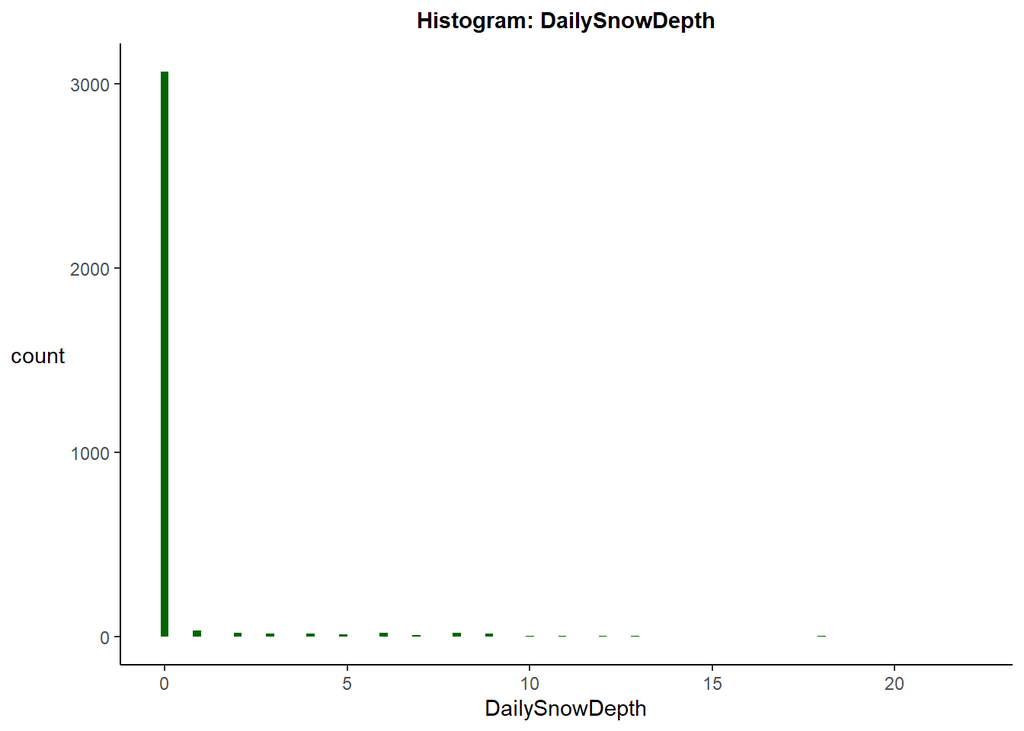

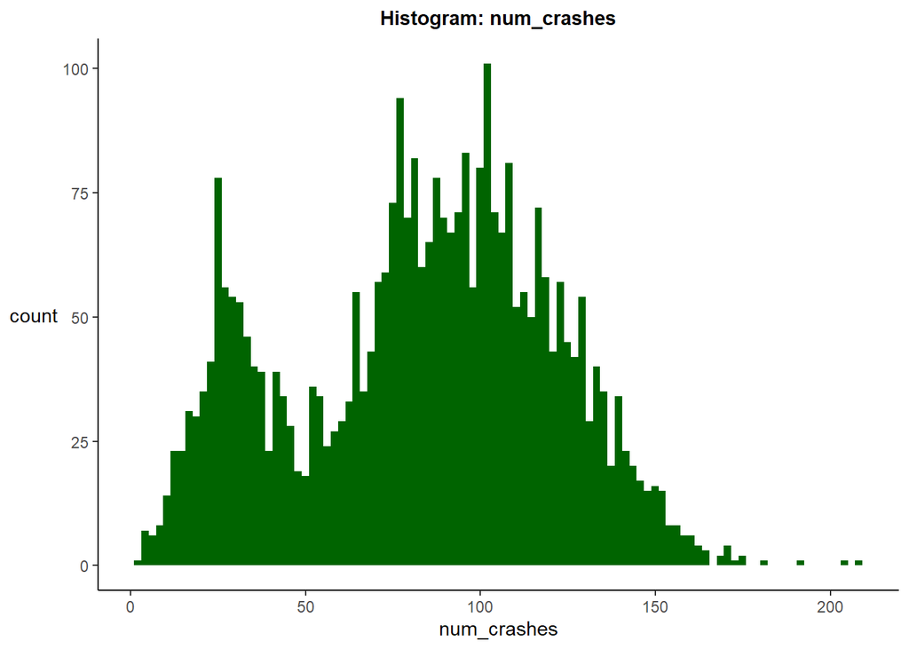

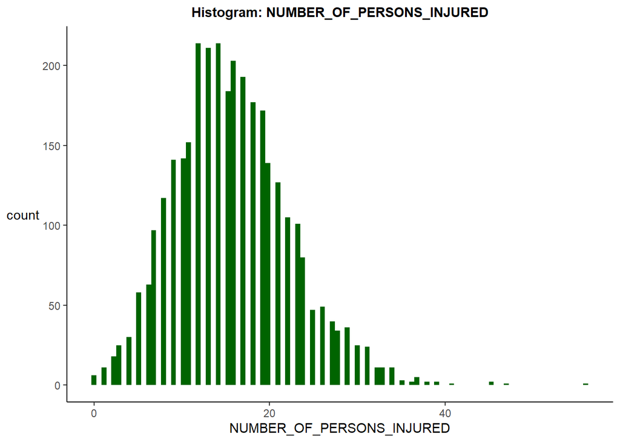

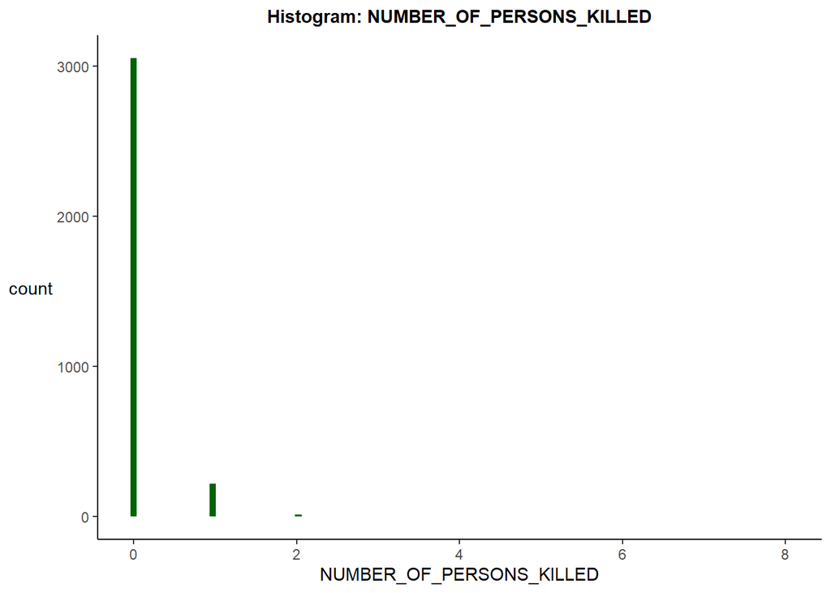

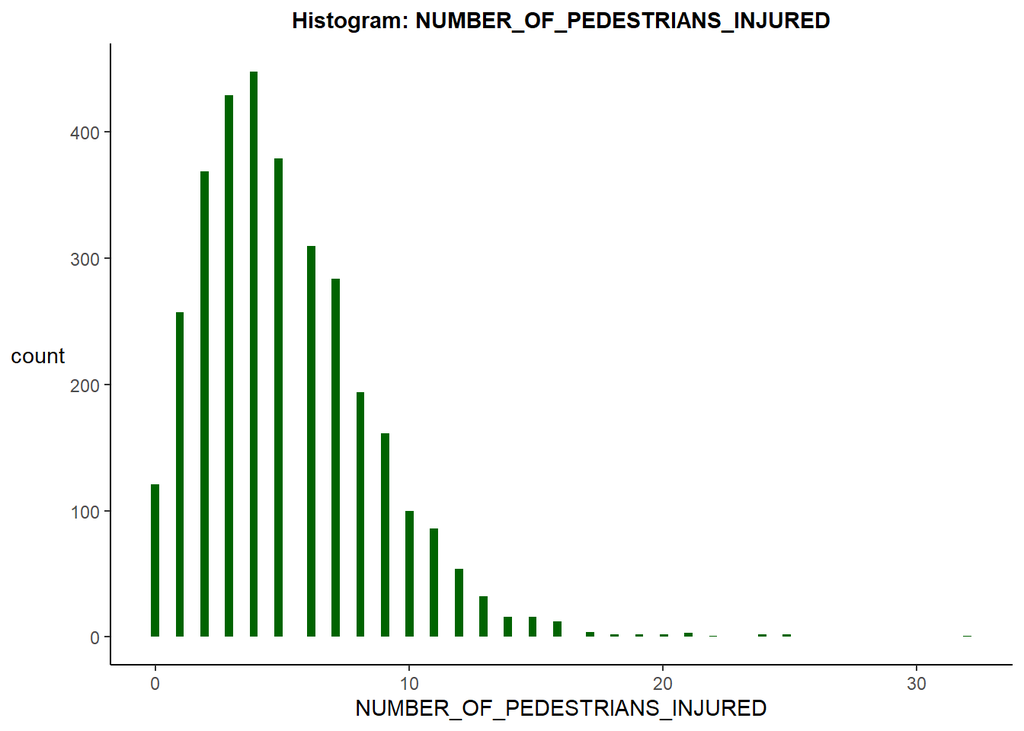

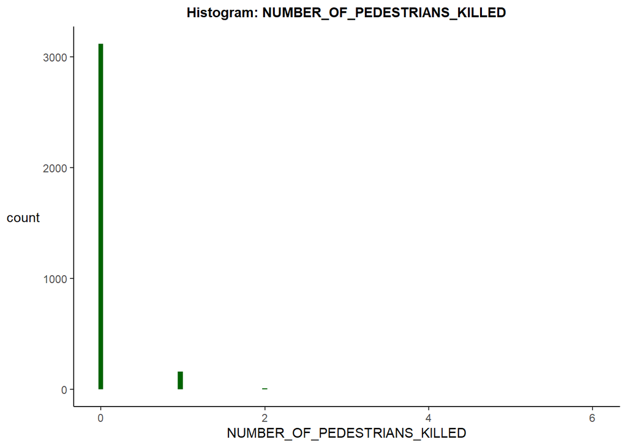

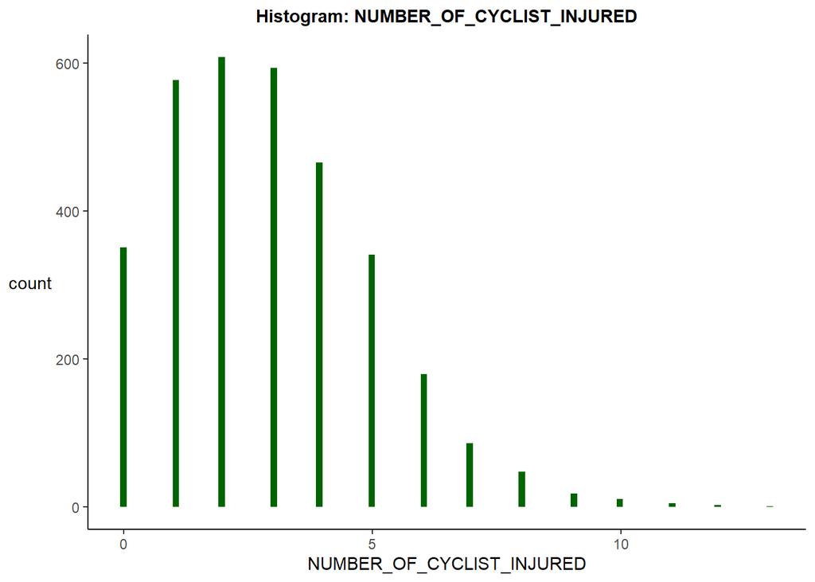

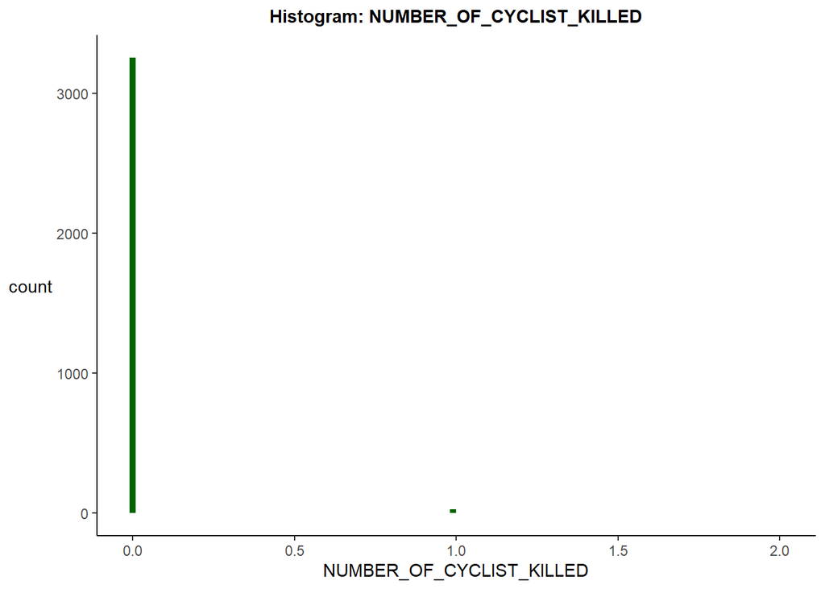

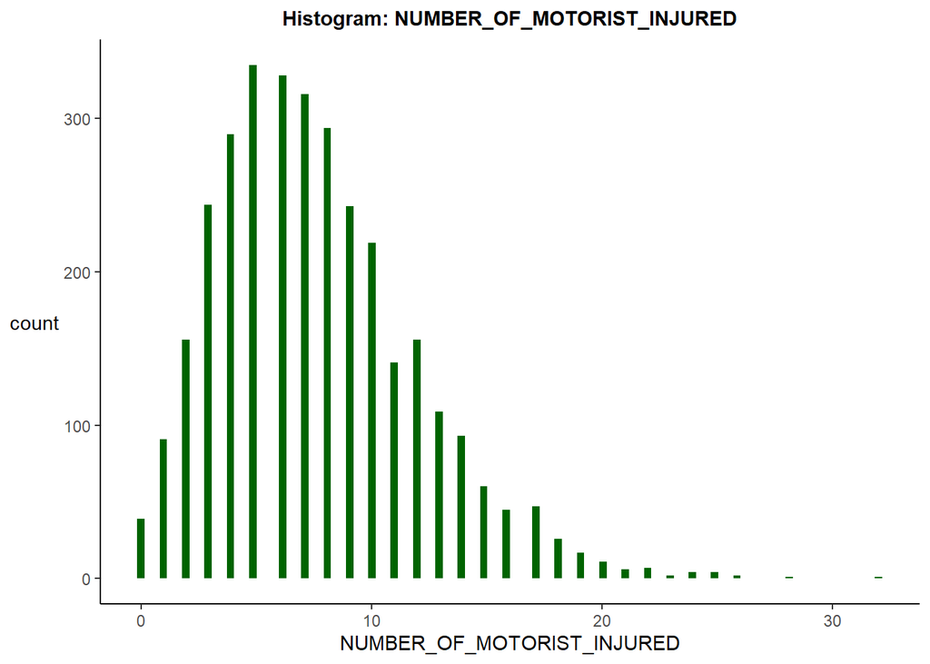

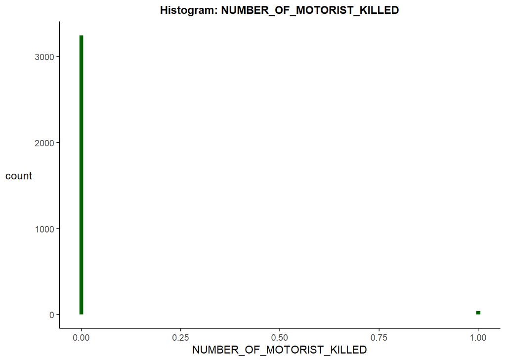

```r
#print each histogram iteratively
walk(items_of_interest,
     gghist,
     .df = weather_collisions)
```

Noting that all weather items appear to have little variation and are very skewed to 0 (which makes sense since there’s no rain on sunny days), but the number of num_crashes seems bimodal. Number of injury variables are a bit more normal although still a bit weighted at 0, and number killed is also very skewed toward 0.

Since the variation for many of these measures seems to be fairly low, I want to check if there is even any correlation between these items.

## Correlations

```r
# Function to calculate Pearson's correlation coefficient
#
# Parameters:
# .df: dataset
# .items: vector of string names in .df to calculate correlations among
#
# Returns:
# Tibble containing Pearson's correlation coefficient, N, and P value for every combination
# of pairs in .items input

correlations_tibble <- function(.df, .items) {

  # initialize a list which will contain named vectors of .items values for reference when correlating
  item_vectors <- list()

  #for every variable in .items, extract the column as a vector and append to list with .items name
  for (i in .items) {
    # extract vector of i values
    values <- .df %>%
      pull(!!sym(i))
    #append to list with variable name
    item_vectors[[i]] <- values
  }

  #calculating correlations for every combination of .items
  for (i in seq(1, length(.items))) {
    for (j in seq(i, length(.items))){

      #reference item_vectors by name for psych::corr.test correlations calculation
      corr_output <- psych::corr.test(item_vectors[[.items[i]]], item_vectors[[.items[j]]])

      #extract and round correlation coefficient
      corr_coef <- round(corr_output$r, 4)
      #extract number of cases
      n_val <- corr_output$n
      #extract p value for correlation
      p_val <- round(corr_output$p, 4)

      #nicely format these values, with appropriate variable names from .items
      output <- tibble(variable = .items[j],
                       Coefficient = corr_coef,
                       N = n_val,
                       `P Value` = p_val) %>%
        pivot_longer(cols = c("Coefficient", "N", "P Value"), names_to = "Statistic", values_to = .items[i])

      #these next lines of code deal with outputting all combinations of coefficients in one tibble
      #if correlating the same item, assign output to tibble initially
      if (i == j) {
        corr_tibble <- output
      } else { #else append correlations to this tibble
        corr_tibble %<>%
          rbind(output)
      }
    }

    #if first element of .items, assign correlations to final object
    if (i == 1) {
        final <- corr_tibble
      } else { #otherwise join iterative element correlations to first tibble
        final %<>%
          left_join(corr_tibble, by = c('variable', 'Statistic'))
      }
  }

  #lastly, replace all NA with empty strings for easier readability
  final %<>%
    mutate_all(~replace(., is.na(.), ""))

  #return tibble of correlations for all combinations of .items
  return(final)
}
```

```r
correlations_tibble(.df = weather_collisions,
                    .items = items_of_interest) %>%
  kable_table("Correlations table, items of interest") %>%
  scroll_box()
```

Correlations table, items of interest

| variable | Statistic | DailyPrecipitation | DailySnowfall | DailySnowDepth | num_crashes | NUMBER_OF_PERSONS_INJURED | NUMBER_OF_PERSONS_KILLED | NUMBER_OF_PEDESTRIANS_INJURED | NUMBER_OF_PEDESTRIANS_KILLED | NUMBER_OF_CYCLIST_INJURED | NUMBER_OF_CYCLIST_KILLED | NUMBER_OF_MOTORIST_INJURED | NUMBER_OF_MOTORIST_KILLED |
| --- | --- | --- | --- | --- | --- | --- | --- | --- | --- | --- | --- | --- | --- |
| DailyPrecipitation | Coefficient | 1 |  |  |  |  |  |  |  |  |  |  |  |
| DailyPrecipitation | N | 3287 |  |  |  |  |  |  |  |  |  |  |  |
| DailyPrecipitation | P Value | 0 |  |  |  |  |  |  |  |  |  |  |  |
| DailySnowfall | Coefficient | 0.2149 | 1 |  |  |  |  |  |  |  |  |  |  |
| DailySnowfall | N | 3287 | 3287 |  |  |  |  |  |  |  |  |  |  |
| DailySnowfall | P Value | 0 | 0 |  |  |  |  |  |  |  |  |  |  |
| DailySnowDepth | Coefficient | 0.0023 | 0.2039 | 1 |  |  |  |  |  |  |  |  |  |
| DailySnowDepth | N | 3287 | 3287 | 3287 |  |  |  |  |  |  |  |  |  |
| DailySnowDepth | P Value | 0.8935 | 0 | 0 |  |  |  |  |  |  |  |  |  |
| num_crashes | Coefficient | 0.0241 | -0.0189 | 0.0188 | 1 |  |  |  |  |  |  |  |  |
| num_crashes | N | 3287 | 3287 | 3287 | 3287 |  |  |  |  |  |  |  |  |
| num_crashes | P Value | 0.1665 | 0.2775 | 0.2815 | 0 |  |  |  |  |  |  |  |  |
| NUMBER_OF_PERSONS_INJURED | Coefficient | 0.0746 | -0.0442 | -0.0619 | 0.6176 | 1 |  |  |  |  |  |  |  |
| NUMBER_OF_PERSONS_INJURED | N | 3287 | 3287 | 3287 | 3287 | 3287 |  |  |  |  |  |  |  |
| NUMBER_OF_PERSONS_INJURED | P Value | 0 | 0.0112 | 4e-04 | 0 | 0 |  |  |  |  |  |  |  |
| NUMBER_OF_PERSONS_KILLED | Coefficient | 0.0178 | -0.0165 | -0.0288 | 0.0594 | 0.0671 | 1 |  |  |  |  |  |  |
| NUMBER_OF_PERSONS_KILLED | N | 3287 | 3287 | 3287 | 3287 | 3287 | 3287 |  |  |  |  |  |  |
| NUMBER_OF_PERSONS_KILLED | P Value | 0.3067 | 0.3449 | 0.0983 | 7e-04 | 1e-04 | 0 |  |  |  |  |  |  |
| NUMBER_OF_PEDESTRIANS_INJURED | Coefficient | 0.1592 | 0.0144 | 0.0505 | 0.5854 | 0.6735 | 0.0878 | 1 |  |  |  |  |  |
| NUMBER_OF_PEDESTRIANS_INJURED | N | 3287 | 3287 | 3287 | 3287 | 3287 | 3287 | 3287 |  |  |  |  |  |
| NUMBER_OF_PEDESTRIANS_INJURED | P Value | 0 | 0.4091 | 0.0038 | 0 | 0 | 0 | 0 |  |  |  |  |  |
| NUMBER_OF_PEDESTRIANS_KILLED | Coefficient | 0.0098 | -0.0109 | -0.0217 | 0.0771 | 0.0822 | 0.8816 | 0.1061 | 1 |  |  |  |  |
| NUMBER_OF_PEDESTRIANS_KILLED | N | 3287 | 3287 | 3287 | 3287 | 3287 | 3287 | 3287 | 3287 |  |  |  |  |
| NUMBER_OF_PEDESTRIANS_KILLED | P Value | 0.5762 | 0.5305 | 0.2145 | 0 | 0 | 0 | 0 | 0 |  |  |  |  |
| NUMBER_OF_CYCLIST_INJURED | Coefficient | -0.0862 | -0.1165 | -0.1677 | 0.242 | 0.4289 | 0.0302 | 0.0593 | 0.0331 | 1 |  |  |  |
| NUMBER_OF_CYCLIST_INJURED | N | 3287 | 3287 | 3287 | 3287 | 3287 | 3287 | 3287 | 3287 | 3287 |  |  |  |
| NUMBER_OF_CYCLIST_INJURED | P Value | 0 | 0 | 0 | 0 | 0 | 0.0834 | 7e-04 | 0.058 | 0 |  |  |  |
| NUMBER_OF_CYCLIST_KILLED | Coefficient | 0.0353 | -0.0096 | -0.0202 | -0.0032 | 0.009 | 0.465 | 0.0142 | 0.181 | -0.0064 | 1 |  |  |
| NUMBER_OF_CYCLIST_KILLED | N | 3287 | 3287 | 3287 | 3287 | 3287 | 3287 | 3287 | 3287 | 3287 | 3287 |  |  |
| NUMBER_OF_CYCLIST_KILLED | P Value | 0.0429 | 0.5814 | 0.2475 | 0.8524 | 0.6059 | 0 | 0.417 | 0 | 0.7124 | 0 |  |  |
| NUMBER_OF_MOTORIST_INJURED | Coefficient | 0.031 | -0.0215 | -0.0512 | 0.396 | 0.8004 | 0.0209 | 0.2288 | 0.0296 | 0.1285 | 0.0053 | 1 |  |
| NUMBER_OF_MOTORIST_INJURED | N | 3287 | 3287 | 3287 | 3287 | 3287 | 3287 | 3287 | 3287 | 3287 | 3287 | 3287 |  |
| NUMBER_OF_MOTORIST_INJURED | P Value | 0.0757 | 0.2187 | 0.0033 | 0 | 0 | 0.2299 | 0 | 0.0893 | 0 | 0.7633 | 0 |  |
| NUMBER_OF_MOTORIST_KILLED | Coefficient | -0.0033 | -0.0122 | -0.0123 | -0.01 | -0.0102 | 0.3458 | -0.0101 | -0.0023 | 0.01 | -0.0105 | -0.0143 | 1 |
| NUMBER_OF_MOTORIST_KILLED | N | 3287 | 3287 | 3287 | 3287 | 3287 | 3287 | 3287 | 3287 | 3287 | 3287 | 3287 | 3287 |
| NUMBER_OF_MOTORIST_KILLED | P Value | 0.8516 | 0.4857 | 0.4807 | 0.5648 | 0.5592 | 0 | 0.5612 | 0.8945 | 0.5658 | 0.5476 | 0.411 | 0 |

It seems that precipitation is clearly not a standout indicator for car collisions in Manhattan, if so, more variance in the car collisions would be explained by that in weather.

# Main Analysis

The model I’ve chosen includes DailyPrecipitation (Total liquid content, water equivalent of precipitation in inches (hundreths)), DailySnowfall (Daily amount of snowfall in inches (tenths)), and DailySnowDepth (Daily reading of snow on the ground in whole inches).

DailyPrecipitation is the main variable included to assess how precipitation impacts collisions, DailySnowfall is included because I believe snowfall specifically could have a different effect on collisions than liquid rainfall, and DailySnowDepth is included on the assumption that snow on the ground, separate from precipitation, could increase collisions.

Although this model is relatively simple, I think it would be fun to try some different regression algorithms and calculate the root mean square error of each to see if any perform particularly better than OLS.

## Model Exploration

For model evaluation, I will split the analysis dataset into training and testing blocks to measure model performance. While a random 75% of observations will be used for training, the remaining 25% will be reserved for testing. I’ve selected 10 models to use on the training data and will then use these models to predict the outcomes of the testing data and calculate a RMSE.

```r
set.seed(1) #set random number generator seed

#training data is random 75% of total
train <- weather_collisions %>%
  slice_sample(prop = 0.75) %>%
  print()

#test portion is 25%
#using date since it is unique id, select remaining rows in weather_collisions
test <- weather_collisions %>%
  filter(!(date %in% train$date)) %>%
  print()
```

```r
#double check no overlap
train %>%
  inner_join(test, by = "date")
#0 rows, lgtm
```

```r
# Function to run a variety of regression algorithms and compare root mean square errors
#
# Parameters:
# .model_formula: string object of regression formula, separating dependent from rhs with ~
# .training_data: training set of analysis dataset
# .testing_data: testing set of analysis dataset
#
# Returns:
# Tibble containing model name and calculated RMSE for 10 models

rmse_exploration <- function(.model_formula, .training_data, .testing_data) {

  #extract dependent from model_formula, replace any white spaces with empty string
  .dependent <- gsub("\\s", "", str_extract(.model_formula, ".*(?=~)"))

  #extract independents from model formula as vector
  .independents <- unlist(strsplit(gsub("\\s", "", gsub("\\+", ",", str_extract(.model_formula, "(?<=~).*"))), ","))

  #convert .model_formula from string to formula
  .model_formula <- as.formula(.model_formula)

  #extract target_values from test data for rmse calculations
  .target_values <- .testing_data %>%
    pull(!!sym(.dependent))

  # set seed for models that will require randomness
  set.seed(42)

  #Begin Analyses

  #OLS

  #ols model
  ols_model <- lm(.model_formula, .training_data)
  #test predictions
  ols_predict <- predict(ols_model, newdata = .testing_data)
  #rmse
  ols_rmse <- sqrt(mean((.target_values - ols_predict)^2))
  #rmse tibble OLS
  ols_rmse_tibble <- tibble(Model = "OLS",
                     RMSE = ols_rmse)

  # Gaussian GLM

  #gaussian model
  gaussian_model <- glm(.model_formula, family = "gaussian", data = .training_data)
  #test predictions
  gauss_predict <- predict(gaussian_model, newdata = .testing_data)
  #rmse
  gauss_rmse <- sqrt(mean((.target_values - gauss_predict)^2))
  #tibble output
  gaussian_rmse_tibble <- tibble(Model = "Gaussian",
                          RMSE = gauss_rmse)

  # Poisson GLM

  #poisson model
  poisson_model <- glm(.model_formula, family = "poisson", data = .training_data)
  #test predictions
  poisson_predict <- predict(poisson_model, newdata = .testing_data)
  #rmse
  poisson_rmse <- sqrt(mean((.target_values - poisson_predict)^2))
  #rmse for poisson
  poisson_rmse_tibble <- tibble(Model = "Poisson",
                         RMSE = poisson_rmse)

  # Gamma GLM

  #gamma model
  gamma_model <- glm(.model_formula, family = "Gamma", data = .training_data)
  #test predictions
  gamma_predict <- predict(gamma_model, newdata = .testing_data)
  #rmse
  gamma_rmse <- sqrt(mean((.target_values - gamma_predict)^2))
  #rmse for gamma
  gamma_rmse_tibble <- tibble(Model = "Gamma",
                       RMSE = gamma_rmse)

  # Tweedie GLM

  #extract maximum likelihood estimation of tweedie index parameter for model
  #full dataset
  tweedie_param <- tweedie.profile(.model_formula, data = weather_collisions)

  #given DailyPrecipitation distribution, xi value between 1-2 makes sense
  #mle is exactly 1.5 - nice

  #run tweedie model, using mle of tweedie index param
  tweedie_model <- glm(.model_formula, family = tweedie(var.power = tweedie_param$xi.max), data = .training_data)
  #test predictions
  tweedie_predict <- predict(tweedie_model, newdata = .testing_data)
  #rmse
  tweedie_rmse <- sqrt(mean((.target_values - tweedie_predict)^2))
  #rmse for tweedie
  tweedie_rmse_tibble <- tibble(Model = "Tweedie",
                         RMSE = tweedie_rmse)


  #vectors of dependent value and matrix independent values for glmnet functions
  #train data - dependent
  y_train <- .training_data %>%
    pull(!!sym(.dependent))
  #train data - independent
  x_train <- .training_data %>%
    select(all_of(.independents)) %>%
    data.matrix()

  #test data - dependent
  y_test <- .testing_data %>%
    pull(!!sym(.dependent))
  #test data - independent
  x_test <- .testing_data %>%
    select(all_of(.independents)) %>%
    data.matrix()


  # Lasso

  #k fold cross validation for lambda with lowest test mse
  lasso_cross_val <- cv.glmnet(x_train, y_train, alpha = 1)
  #lasso model with lambda
  lasso_model <- glmnet(x_train, y_train, alpha = 1, lambda = lasso_cross_val$lambda.min)

  #predict test independent with test dependents, cross validated lambda
  lasso_predict <- predict(lasso_model, newx = x_test, s = lasso_cross_val$lambda.min)

  #lasso rmse calcualtion
  lasso_rmse <- sqrt(mean((y_test - lasso_predict)^2))

  lasso_rmse_tibble <- tibble(Model = "Lasso",
                              RMSE = lasso_rmse)

  # Ridge

  #k fold cross validation for lambda with lowest test mse
  ridge_cross_val <- cv.glmnet(x_train, y_train, alpha = 0)
  #ridge model with lambda
  ridge_model <- glmnet(x_train, y_train, alpha = 0, lambda = ridge_cross_val$lambda.min)

  #predict test independent with test dependents, cross validated lambda
  ridge_predict <- predict(ridge_model, newx = x_test, s = ridge_cross_val$lambda.min)

  #ridge rmse calculation
  ridge_rmse <- sqrt(mean((y_test - ridge_predict)^2))

  ridge_rmse_tibble <- tibble(Model = "Ridge",
                              RMSE = ridge_rmse)

  # Elastic Net

  #vector of potential alpha values, from 0.05 to 0.95 (0 and 1 are used for Ridge and Lasso, respectively) at 0.05 intervals (doesn't need to be crazy specific)
  elastic_net_alphas <- seq(0.05, 0.95, by = .05)
  #initial list of alphas and their respective rmse for choosing best
  alphas_rmse <- list()

  map(elastic_net_alphas, function(.alpha){
  #k fold cross validation for lambda with lowest test mse
  eln_cross_val <- cv.glmnet(x_train, y_train, alpha = .alpha)
  #elastic net model with lambda, and .alpha
  elm_model <- glmnet(x_train, y_train, alpha = .alpha, lambda = eln_cross_val$lambda.min)

  #predict test independent with test dependents, cross validated lambda, rmse calculation
  eln_predict <- predict(elm_model, newx = x_test, s = eln_cross_val$lambda.min)
  eln_rmse <- sqrt(mean((y_test - eln_predict)^2))
  #append rmse and alpha as name to list
  alphas_rmse[[as.character(.alpha)]] <<- eln_rmse
  })
  #index in list of lowest rmse
  min_index <- which.min(unlist(alphas_rmse))
  #extract best alpha and rmse from list of all results
  best_alpha <- as.double(names(alphas_rmse)[min_index])
  lowest_rmse <- unname(unlist(alphas_rmse))[min_index]

  eln_rmse_tibble <- tibble(Model = "Elastic Net",
                              RMSE = lowest_rmse)

  # Random Forest

  #random forest model
  rf_model <- randomForest(.model_formula, data = .training_data)
  #predict test data outcome
  rf_predict <- predict(rf_model, newdata = .testing_data)
  #calculate rmse
  rf_rmse <- sqrt(mean((.target_values - rf_predict)^2))
  #table
  rf_rmse_tibble <- tibble(Model = "Random Forest",
                              RMSE = rf_rmse)

  # Neural Net

  #neural net model, first hidden layer has 3 nodes, second has 2
  #JM: adjusting number of layers/nodes doens't seem to affect this model performance very much
  nn_model <- neuralnet(.model_formula, data = .training_data, hidden = c(3,2))
  #predict test outcomes
  nn_predict <- compute(nn_model, .testing_data)
  #calculate rmse
  nn_rmse <- sqrt(mean((.target_values - nn_predict$net.result)^2))
  #table rmse
  nn_rmse_tibble <- tibble(Model = "Neural Net",
                              RMSE = nn_rmse)

  # End of Analyses

  #list rmse table output from each model
  rmse_tables <- list(ols_rmse_tibble,
                      gaussian_rmse_tibble,
                      poisson_rmse_tibble,
                      gamma_rmse_tibble,
                      tweedie_rmse_tibble,
                      lasso_rmse_tibble,
                      ridge_rmse_tibble,
                      eln_rmse_tibble,
                      rf_rmse_tibble,
                      nn_rmse_tibble)

  #bind all rmse_tables together to compare model performance
  rmse_output <- map_dfr(rmse_tables, rbind)

  return(rmse_output)
}
```

```r
rmse_exploration(.model_formula = "num_crashes ~ DailyPrecipitation + DailySnowfall + DailySnowDepth",
                  .training_data = train,
                  .testing_data = test) %>%
  kable_table('RMSE Analysis for several algorithms')
```

1.5 2 2.5 3 3.5 4 4.5 5 ……..Done.

RMSE Analysis for several algorithms

| Model | RMSE |
| --- | --- |
| OLS | 38.19244 |
| Gaussian | 38.19244 |
| Poisson | 85.92799 |
| Gamma | 89.90765 |
| Tweedie | 89.81949 |
| Lasso | 38.16160 |
| Ridge | 38.16377 |
| Elastic Net | 38.16160 |
| Random Forest | 38.30405 |
| Neural Net | 38.16160 |

Lasso, Ridge, and Neural Net regressions are all able to predict the dependent value in the testing dataset just slightly better than OLS. However, I do not think the difference is large enough to warrant using any of these models. For simplicity, I will move forward using OLS for this analysis.

## Linear Model

```r
# Function to run a linear model
#
# Parameters:
# .lhs: string object of dependent variable in regression formula
# .df: analysis dataset
# .rhs: string object of right hand side of regression formula
# .round: optional integer value specifying number of significant digits to round to, defaults to 5
#
# Returns:
# Tibble containing lm model output including:
#   R squared
#   Adjusted R squared
#   F statistic
#   F statistic P value
#   Number of observations in the model
#   Estimate, Standard Error, T value, and P value for each covariate

lm_function <- function(.lhs, .df, .rhs, .round = 5) {

  #convert .lhs and .rhs into lm formula
  model_formula <- as.formula(paste(.lhs, "~", .rhs, sep = " "))
  #run model
  model <- lm(model_formula, .df)
  #get model summary
  model_summary <- summary(model)

  #extract adjusted r squared and mult r squared from model summary
  # round to 5 decimal places
  adj_r <- model_summary$adj.r.squared
  mult_r <- model_summary$r.squared

  #use anova to extract f stat and it's p value from model
  f_stat <- anova(model)$F[1]
  f_stat_p <- anova(model)$Pr[1]

  #number of observations used
  n_obs <- nobs(model)

  #extract estimate, std error, t and p values from model summary and table nicely
  coefficients <- as.data.frame(model_summary$coefficients) %>%
    rownames_to_column() %>%
    as_tibble() %>%
    #filtering out intercept row of coefficients
    filter(rowname != "(Intercept)") %>%
    #rename several items
    rename("Variable" = rowname,
           "Std_Error" = `Std. Error`,
           "t_value" = `t value`,
           "p_value" = `Pr(>|t|)`) %>%
    #round every numeric column to .round value
    mutate(across(where(is.numeric), ~ round(., .round))) %>%
    #create item displaying formula, paste p val stars to p value
    mutate(Dependent = .lhs,
           Formula = .rhs,
           p_value = paste(p_value, stars.pval(p_value))) %>%
    relocate(Formula) %>%
    # pivot wider by Variables, 1 row per lm run, more useful when there's multiple regressors
    # vary names slowest to group output by each lhs item
    pivot_wider(id_cols = c('Dependent', 'Formula'), names_from = "Variable", values_from = c("Estimate", "Std_Error", "t_value", "p_value"), names_vary = "slowest")

  #manually build lm output tibble including formula, r squared, f stat
  lm_output <- tibble(Dependent = .lhs,
                      Formula = .rhs,
                      r_squared = mult_r,
                      adj_r_squared = adj_r,
                      F_statistic = f_stat,
                      F_p_value = f_stat_p,
                      n_obs = n_obs) %>%
    #round all numeric output
    mutate(across(where(is.numeric), ~ round(., .round))) %>%
    #append stars to F stat p value
    mutate(F_p_value = paste(F_p_value, stars.pval(F_p_value))) %>%
    #join coefficients by formula
    left_join(coefficients, by = c("Dependent", "Formula"))

  return(lm_output)
}
```

```r
#vector of dependent variable names to run on model
dependents <- weather_collisions %>%
  select(num_crashes, matches("NUMBER")) %>%
  names()
```

```r
#run them on lm function with .rhs being only DailyPrecipitation
map_dfr(dependents,
        lm_function,
        .df = weather_collisions,
        .rhs = "DailyPrecipitation + DailySnowfall + DailySnowDepth") %>%
  kable_table("Results of linear models, collision variables on daily precipitation") %>%
  scroll_box()
```

Results of linear models, collision variables on daily precipitation

| Dependent | Formula | r_squared | adj_r_squared | F_statistic | F_p_value | n_obs | Estimate_DailyPrecipitation | Std_Error_DailyPrecipitation | t_value_DailyPrecipitation | p_value_DailyPrecipitation | Estimate_DailySnowfall | Std_Error_DailySnowfall | t_value_DailySnowfall | p_value_DailySnowfall | Estimate_DailySnowDepth | Std_Error_DailySnowDepth | t_value_DailySnowDepth | p_value_DailySnowDepth |
| --- | --- | --- | --- | --- | --- | --- | --- | --- | --- | --- | --- | --- | --- | --- | --- | --- | --- | --- |
| num_crashes | DailyPrecipitation + DailySnowfall + DailySnowDepth | 0.00179 | 0.00088 | 1.91646 | 0.16634 | 3287 | 2.97810 | 1.73570 | 1.71580 | 0.08629 . | -1.38071 | 0.82291 | -1.67784 | 0.09347 . | 0.47530 | 0.33942 | 1.40031 | 0.16151 |
| NUMBER_OF_PERSONS_INJURED | DailyPrecipitation + DailySnowfall + DailySnowDepth | 0.01191 | 0.01101 | 18.49660 | 2e-05 *** | 3287 | 1.48716 | 0.30764 | 4.83407 | 0 *** | -0.41925 | 0.14586 | -2.87439 | 0.00407 ** | -0.17463 | 0.06016 | -2.90272 | 0.00372 ** |
| NUMBER_OF_PERSONS_KILLED | DailyPrecipitation + DailySnowfall + DailySnowDepth | 0.00138 | 0.00047 | 1.04557 | 0.3066 | 3287 | 0.01739 | 0.01460 | 1.19127 | 0.23364 | -0.00600 | 0.00692 | -0.86650 | 0.38628 | -0.00411 | 0.00285 | -1.43905 | 0.15023 |
| NUMBER_OF_PEDESTRIANS_INJURED | DailyPrecipitation + DailySnowfall + DailySnowDepth | 0.02885 | 0.02796 | 85.68592 | 0 *** | 3287 | 1.47834 | 0.15685 | 9.42534 | 0 *** | -0.13584 | 0.07436 | -1.82673 | 0.06783 . | 0.09913 | 0.03067 | 3.23187 | 0.00124 ** |
| NUMBER_OF_PEDESTRIANS_KILLED | DailyPrecipitation + DailySnowfall + DailySnowDepth | 0.00065 | -0.00027 | 0.31252 | 0.57617 | 3287 | 0.00797 | 0.01204 | 0.66170 | 0.50821 | -0.00296 | 0.00571 | -0.51775 | 0.60467 | -0.00261 | 0.00236 | -1.10751 | 0.26815 |
| NUMBER_OF_CYCLIST_INJURED | DailyPrecipitation + DailySnowfall + DailySnowDepth | 0.03996 | 0.03908 | 25.42594 | 0 *** | 3287 | -0.38135 | 0.09437 | -4.04119 | 5e-05 *** | -0.17494 | 0.04474 | -3.91011 | 9e-05 *** | -0.16176 | 0.01845 | -8.76560 | 0 *** |
| NUMBER_OF_CYCLIST_KILLED | DailyPrecipitation + DailySnowfall + DailySnowDepth | 0.00185 | 0.00093 | 4.10400 | 0.04286 * | 3287 | 0.01003 | 0.00466 | 2.15143 | 0.03151 * | -0.00174 | 0.00221 | -0.78596 | 0.43195 | -0.00089 | 0.00091 | -0.97269 | 0.33078 |
| NUMBER_OF_MOTORIST_INJURED | DailyPrecipitation + DailySnowfall + DailySnowDepth | 0.00393 | 0.00302 | 3.16478 | 0.07533 . | 3287 | 0.39728 | 0.20113 | 1.97527 | 0.04832 * | -0.10134 | 0.09536 | -1.06274 | 0.28798 | -0.10457 | 0.03933 | -2.65859 | 0.00788 ** |
| NUMBER_OF_MOTORIST_KILLED | DailyPrecipitation + DailySnowfall + DailySnowDepth | 0.00025 | -0.00066 | 0.03501 | 0.85158 | 3287 | -0.00032 | 0.00513 | -0.06322 | 0.9496 | -0.00131 | 0.00243 | -0.53757 | 0.59091 | -0.00058 | 0.00100 | -0.57720 | 0.56384 |

The table above presents the linear model results regressing number of vehicle collisions and number of injuries and fatalities on daily precipitation, snowfall, and snow depth.

Regarding number of car collisions, the estimates on DailyPrecipitation and DailySnowfall are only significant at the 10% level, and DailylSnowDepth is not significant. Notably, the precipitation and snowfall estimates are positive and negative, respectively. Precipitation appears to be associated with an increase in the number of crashes in Manhattan between 2013 - 2022 as I hypothesized, but I did not expect snowfall itself to be correlated with a decrease. Perhaps there are fewer drivers on the road during snowy days, which would likely cause the gross number of crashes to be lower.

On average, each additional inch of daily precipitation is associated with one and a half persons injured from car collisions. Both snowfall and snow depth have significant negative estimates with persons injured which was unexpected, but which perhaps I can contribute to the same theory that on snowy days there are fewer drivers out.

An additional inch of precipitation is associated on average with a reduction in the number of cyclists injured by about 0.4 but an increase in the number of cyclists killed by 0.01 in car collisions. Perhaps on average there are fewer cyclists on the road during rainy days to get injured, but rainfall appears to increase the risk of fatality.

# Discussion

The findings above are not without limitations.

There are many other potentially influential predictors of car collisions besides weather, and this is evidenced by the low correlations, relatively high RMSE, and low adjusted R squared values presented in this programming sample. A potential next step would be to control for this variation in car collisions not due to weather, but this task could prove difficult since there are likely many factors that contribute to collisions.

However, an easier next step I could take is to do an hourly analysis between weather and collisions instead of a daily one. This would help to reduce model errors by more directly comparing collisions and weather by the time each occur. Regarding collisions, I think it makes sense to average the injuries and fatalities dependents instead of summing. This could partially control for the number of drivers on the road at any given time if my assumption that the number of drivers on the road impacts the number of crashes holds.

The weather data itself and the assumptions I made about it could be improved as well. I am only using weather data collected from the Central Park NOAA weather station and assuming that those observations hold for the entire island of Manhattan. Just because it rains in Midtown does not mean it is raining downtown. I could improve this by gathering weather information from a different source and analyzing it geospatially.